# Who Can Actually Get a State Voter File

Public by law, and you still cannot have it: fifty-one official pages, one downloadable statewide list

Democracy’s Data

Last updated September 13, 2026 at 10:53a EDT

Every state’s voter registration list — the **voter file**, the list of everyone registered to vote, kept so that each person can be handed the right ballot — is a public record. That is the law in all fifty states and the District of Columbia, and it is repeated so often that it sounds like an instruction: go and download it. This brief asks the question the sentence skips. Each jurisdiction publishes an official page telling you how to get its list. If you went to all fifty-one of those pages on one day, at how many could you actually get the file?

## The test

The addresses come from the National Conference of State Legislatures (NCSL), the bipartisan organization that serves the fifty state legislatures and tracks their laws. It keeps a fifty-state survey of who may obtain a voter list, what it contains, and what it may be used for, at https://www.ncsl.org/elections-and-campaigns/access-to-and-use-of-voter-registration-lists. For each jurisdiction the survey carries a link labelled *“<State> Access/Purchase List”*, pointing at that state’s own election-agency page. Those **51 links are the addresses tested here.**

On **2026-08-13** every one of them was requested by a script — an automated program standing in for a person at a browser — one after another, and what happened at each was written down. Did it answer at all? What did the page turn out to be? Did it offer the file for download?

This is the right test because availability is the one question about voter files that reading the law cannot answer. What the file itself is, and the ballot-handling job its columns do, is the subject of the voter-file chapter; this brief measures only the door. One division of labour holds throughout. **The legal facts in this brief are NCSL’s**, and are cited to NCSL. **The retrievability facts are measured here**, and can be re-measured by anyone.

## The data

The scan produced five small tables, and every number below is computed from them. `funnel.csv` narrows the 51 jurisdictions stage by stage, in `stage` and `states`. `link_rot.csv` names each address that failed, with the `outcome` it produced. `page_shape.csv` counts what the answering pages actually are, in `reading` and `states`. `claimed_downloads.csv` follows every link that claims to be a data file, recording `what_the_link_is`, `is_the_voter_list` and `bytes`. Behind them all sits `scan.csv`, one row per jurisdiction: the HTTP status (the three-digit code a web server answers with — 200 for a page, 403 for a refusal, 404 for nothing there), the size, and whether the page shows a login, an application or a fee.

One row shows how those columns were read. North Carolina’s: status 200, so the page answered; a web page of 105,347 bytes rather than a PDF; the words *application* and *fee* appear on it, as they do on most; and 183 of its links end in a data-file extension, `.zip`, `.csv` and the like — a count of markup, which says nothing about what any of those files is. Ohio’s row reads 403, a refusal. Something came back, 1,253,632 bytes of it, but it is the server’s notice turning the script away, not the election office’s page, so the flags read from it describe the wrong document and the scan counts Ohio as blocked rather than as answering. Notice that nothing in North Carolina’s row says the list is downloadable — a page can mention a fee and still give the file away. Settling that took opening the links, which is the last stage of the funnel below.

One more table was not scanned but compiled. `price.csv` lays the two published price lists for a statewide file side by side: the U.S. Election Assistance Commission’s (the EAC, the federal agency HAVA created to help states run elections), in `eac_price_usd`, and the July 2026 table kept by Ballotpedia, a nonprofit encyclopedia of American politics, in `bp_price` and `bp_price_usd`. Ballotpedia’s column is kept as the prose it prints, because for 8 jurisdictions the price is a rule rather than a single amount: per record, per staff hour, by subscription. Flattening a rule into a dollar figure would invent the figure.

Two cleaning decisions matter. Nothing was retried or repaired: a page that refused an automated request on the day is recorded as refusing, because that refusal is a finding rather than a nuisance. And the results are frozen at the scan date. A brief whose numbers changed every time it was rebuilt would be reporting the weather, not a measurement.

> **Before you read on, commit to a number.** Every state’s registration list is a public record. Fifty-one jurisdictions each publish a page telling you how to get theirs. **On how many of those pages can you actually download the file?** Write the number down.

## What it says about democracy

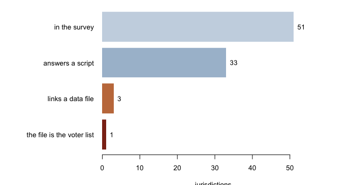

**Figure 1. What happened at fifty-one addresses on one day.** A funnel fits this question because the answer narrows in stages: every jurisdiction, then the pages that answered, then the pages linking any file, then the file that really is the voter list. The finding is how few survive each cut.

| Stage | States |
| --- | --- |
| Jurisdictions in the survey | 51 |
| Address answers a script | 33 |
| …and links a data file of any kind | 3 |
| …and that file is the voter list | 1 |

**33 of 51 addresses answered.** 10 refused an automated request outright with HTTP 403: the page exists, and a person with a browser can probably read it, but a script is turned away. And 8 failed before any page came back — a dead link, or a server that never answered:

| State | Outcome |
| --- | --- |
| Arkansas | dead link |
| Colorado | no connection |
| Delaware | no connection |
| Idaho | dead link |
| Louisiana | dead link |
| South Dakota | dead link |
| Utah | no connection |
| West Virginia | dead link |

That is 15.7% of the survey’s own links dead or unreachable on the day they were tried. The survey is careful work; the pages underneath it move.

Of the 33 pages that answered, here is what they are:

| The page… | States (of 33) |
| --- | --- |
| presents an application or request form | 26 |
| mentions a fee, a cost or a purchase | 23 |
| asks you to log in | 11 |
| is a PDF form to print and post | 6 |

**Asking is the normal case.** 26 of the 33 answering pages present an application or a request form, 23 mention a fee or a purchase, 11 want a login, and 6 are a PDF to print and post. This is the ordinary condition of the American voter file: not secret, not published — applied for.

Only 3 of the answering pages link a data file of any kind, and a link is only a promise about what is behind it, so all 3 were opened:

| State | What the link actually is | Is it the voter list? | Bytes |
| --- | --- | --- | --- |
| North Carolina | ncvoter_Statewide.zip – the statewide registration file | yes | 519,773,993 |
| Maine | an absentee-ballot file: one row per absentee request, with party and status | no | 9,485,160 |
| Virginia | a candidate and committee directory | no | – |

2 of the 3 are not the voter list. Virginia’s is a directory of candidates and committees. Maine’s carries one row per absentee ballot — a real and interesting file, posted openly, and not what the page was asked for. A scan that only counted whether a link existed would have scored both as successes.

So the answer to the question above is **1**. One jurisdiction of fifty-one puts its statewide voter list at an address anyone can download: **North Carolina**, 496 MB, no login, no form, no fee. That gap between *public* and *obtainable* is not a paperwork curiosity. It decides who can check claims about the electorate. Campaigns and vendors, who pay and wait, can; a citizen or a student mostly cannot. Much of what nobody knows about American elections lives in that gap.

What asking costs is its own measurement problem, because the two published price tables disagree:

| What the two tables say | Jurisdictions |
| --- | --- |
| Both give one plain price, and it is the same | 25 |
| Both give one plain price, and it is not | 18 |
| The 2026 price is not a single amount | 8 |

They agree on 25 jurisdictions and differ on 18 of the 43 where both print one plain number. Some differences are a few dollars. Others are not:

| State | EAC, 2020 | Ballotpedia, 2026 |
| --- | --- | --- |
| Alabama | $37,000 | $1,000 |
| Nevada | $20,000 | $0 |
| California | $15,000 | $100 |
| Indiana | $0 | $5,000 |
| New Mexico | $5,215 | $600 |
| Kentucky | $2,000 | $4,000 |

Alabama matters most, because its `$37,000` is the number everybody quotes as the top of the national range. The 2026 compilation prices the same list at `$1,000`. The federal table prints no date anywhere on it; the file’s own properties record that it was made in October 2020, which makes it 6 years old and not visibly stale. And for 8 jurisdictions a price is not a price at all:

| State | EAC, 2020 | What the state actually charges |
| --- | --- | --- |
| Arizona | $516 | $328.13 plus $0.0000625 per record |
| Michigan | $23 | Cost varies based on time taken to produce report |
| Montana | $1,000 | $5,000 for a year subscription |
| New Hampshire | $275 | $25 for a digital copy, $25 plus $0.50 per thousand names in excess of 2,500 plus shipping for physical copies |
| Tennessee | $2,500 | $75 for digital or $30 per 1,000 voters for paper list |
| Texas | $1,279 | $328.13 + $0.0000625 per voter |
| Virginia | $5,000 | Minimum cost $33, voter list pricing |
| West Virginia | $500 | $1000 for an election cycle subscription |

One row of these tables the scan can settle itself. The EAC prices North Carolina at nothing and the 2026 table at `$25`. The scan went and got the file: 496 MB, nothing signed, nothing paid. On that one jurisdiction the measurement beats both compilations, which is the whole argument for making one.

## What this brief cannot tell you

**It prices nothing itself.** The two tables above are other people’s counting, reproduced and compared. Nothing here was paid and no state was asked what it charges, which is why the 18 disagreements are reported rather than resolved.

**It is not a legal summary.** Who may request a list, what a state redacts, and what uses are permitted are NCSL’s subject and are cited to NCSL, not restated on this brief’s authority.

**It is one day.** The scan is dated 2026-08-13, and 15.7% of the links were already broken when it ran, which tells you how fast this surface moves. Re-running it and reading what changed would itself be a finding.

**And a 403 is not a refusal of access.** 10 states turned away an automated request. A person with a browser may well be able to read those pages and follow the process on them. What is measured here is what a script meets — the honest scope of a scan, not a claim about what a determined citizen can do.

## What you should have learned

- A voter file is public by law in all 51 jurisdictions and downloadable in 1: North Carolina, 496 MB, no login, no form, no fee.
- Asking is the normal case: 26 of the 33 answering pages present an application or request form, and 23 mention a fee.
- 8 of the survey’s 51 links — 15.7% — were dead or unreachable on the day of the scan.
- Of 3 pages linking any data file, only 1 link the voter list; a link that exists is not evidence of what is behind it.
- The two published price tables disagree on 18 of the 43 jurisdictions where both give one plain number, and the federal one carries no date.

## Extensions

None of these is answered above, and every one can be answered from the tables the Sources section hands over.

- `funnel.csv` narrows fifty-one jurisdictions stage by stage in `stage` and `states`. Read it top to bottom. At which stage does the public’s access actually disappear?
- `page_shape.csv` counts, in `reading` and `states`, how many official pages present a form rather than a file. What is the difference, for a citizen, between public and available?
- `link_rot.csv` records each failed address in `outcome`. Count the kinds of failure. What does each kind say about how these pages are maintained?
- `claimed_downloads.csv` marks each linked file in `is_the_voter_list`, with its `bytes`. Work out what someone studying all fifty states would have to do instead of downloading.
- `price.csv` puts two price tables side by side. Sort by the gap between `eac_price_usd` and `bp_price_usd`. Which jurisdictions would you check yourself before quoting either number?
- `price.csv` also marks, in `bp_price_is_one_number`, the jurisdictions whose charge is a rule rather than an amount, spelled out in `bp_price`. What would you have to decide before putting those rows in a column of dollars?

Two stretch ideas point past the spreadsheet. Open your own state’s page, at the address recorded for it in `scan.csv`, and note what a person with a browser meets that a script did not. That is one row of the measurement, re-run. And download North Carolina’s file yourself, then compare its size against the `bytes` recorded here to see whether the list has grown.

## Sources

**Data**

- National Conference of State Legislatures. *Access To and Use Of Voter Registration Lists.* The fifty-state survey, its narrative columns, and the per-jurisdiction “Access/Purchase List” links used as the scan’s addresses. https://www.ncsl.org/elections-and-campaigns/access-to-and-use-of-voter-registration-lists
- The 51 state and District election-agency pages that survey links to, each requested on 2026-08-13. Every address, status, content type and byte count is recorded per jurisdiction in `scan.csv`.
- U.S. Election Assistance Commission. *Availability of State Voter File and Confidential Information.* Eleven pages, captured 29 August 2026. **The document prints no date**; the October 2020 given above is the creation date in the file’s own properties. Its source line names NCSL and others, so it is a compilation of compilations rather than a federal collection. https://www.eac.gov/sites/default/files/voters/Available_Voter_File_Information.pdf
- Ballotpedia. *Availability of state voter files*, the version dated July 2026, captured 29 August 2026. Fifty-one jurisdictions with a price column that is prose rather than a number, which is why it is kept as prose here. https://ballotpedia.org/Availability_of_state_voter_files
- North Carolina State Board of Elections. *Statewide voter registration file*, `ncvoter_Statewide.zip`, 496 MB. https://s3.amazonaws.com/dl.ncsbe.gov/data/; the Board’s own page describing the file is https://www.ncsbe.gov/results-data/voter-registration-data.
- Maine Department of the Secretary of State. Absentee-ballot file, posted as a plain-text export, 9,485,160 bytes.
- Help America Vote Act of 2002, § 303, codified at 52 U.S.C. §21083, https://www.law.cornell.edu/uscode/text/52/21083, which required every state to build a single computerised statewide list and said nothing about what it should contain — the condition the voter-files-source chapter takes as its subject.

**The data itself**

Every figure above is drawn from these tables. They are plain CSV, they open in a spreadsheet, and they are yours to take further.

`claimed_downloads.csv`, `funnel.csv`, `link_rot.csv`, `page_shape.csv`, `price.csv`, `scan.csv`

Two more files here are not data about the subject at all – they are how this chapter checked its own work: `facts.csv`, the individual numbers the text above quotes, and `checks.csv`, the arithmetic verified before anything was drawn.

Why this data cannot be fetched again

```
The dataset behind this chapter is a measurement of one particular
day, and that day cannot be downloaded again — not by you, and not by any
assistant.

WHY NOT. It is a scan: the National Conference of State Legislatures'
50-state survey of voter-list access carries, for each state and the
District of Columbia, a link to that state's own "how to get the
list" page. All 51 of those addresses were opened on 13 August
2026, and what came back was recorded — status codes, content types,
byte counts, whether the page links an actual data file. Send a normal
browser User-Agent header if you repeat this: a bare script is refused
by more of these sites than a browser is, and that difference is a
property of the scan rather than of the states. State websites are rebuilt, moved and re-fenced all
the time; 8 of the survey's own links already failed to resolve on
that first pass. Running the same requests today measures a different
day, which is exactly why the original answers were kept.

WHAT EXISTS INSTEAD. The survey itself is public and current:
https://www.ncsl.org/elections-and-campaigns/access-to-and-use-of-voter-registration-lists
An assistant can take its 51 links and request them all today. The
result will be a legitimate new scan — differences from the numbers
below are real changes in what the states serve, and finding them is
more interesting than reproducing the old ones.

THE PRICES, HOWEVER, CAN BE DOWNLOADED. Two published tables give a
price for all 51 jurisdictions, and both are open:
https://www.eac.gov/sites/default/files/voters/Available_Voter_File_Information.pdf
is the Election Assistance Commission's, with the state, availability
and price table on its page 2. Read the creation date out of the PDF's
own properties before using it, because nothing printed on the
document says when it was written.
https://ballotpedia.org/Availability_of_state_voter_files is the
other, dated on the page itself. Keep its price column as text rather
than as a number: for several states the entry is a rule, such as a
base charge plus a fraction of a cent per record, and reading it as a
number quietly invents an amount. Then put the two side by side. The
disagreement between them is the finding, not an error to resolve.

WHAT YOU CAN STILL CHECK. These numbers identify the 13 August 2026
scan; a rerun should land near them, not on them:
- 51 addresses, one per state plus the District of Columbia
- 33 answered normally, 10 refused a script with a 403, 5 were dead
  links, and 3 never completed a connection
- exactly 1 of the 51 published the voter list for open download:
  North Carolina's statewide file, 496 MB, no login asked
- 8 of the survey's own links did not resolve — about one in six

On the two price tables, which you can download: both cover 51
jurisdictions. The federal one was created on 30 October 2020 and says
so only in its file properties, and its highest price is Alabama at
37,000 dollars, which the 2026 table puts at 1,000. Of the 43
jurisdictions where both give a single plain amount, they agree on 25
and differ on 18. For 8 jurisdictions the 2026 table gives no single
amount at all. Land somewhere else on those counts and either a table
has been revised or the price column has been read as a number when it
is a sentence.
```